# Machine Learning Final Project

ABrunk

October 29, 2018

## Loading Data and Packages

First, load in data and required packages

```r
library(readr)
library(caret)
library(randomForest)
library(rattle)
library(rpart.plot)
library(AppliedPredictiveModeling)
library(corrplot)

pml_training <- read_csv("pml-training.csv")
pml_testing <- read_csv("pml-testing.csv")
```

## Data Cleaning / Pre-Processing

Next, take a few steps to clean the data. Identify variables that are mostly NAs, and any that are not present in the testing data set.

```r
na_count <- sapply(pml_training, function(x)sum(length(which(is.na(x)))))
na_count <- data.frame(na_count)

pml_varlist<-cbind(sapply(pml_testing, function(x)all(is.na(x))),
                   sapply(pml_training, function(x)all(is.na(x))),
                   na_count)

names(pml_varlist) <- c("testing","training","training.na")
```

Remove all variables that aren’t part of the test set, as well as all unique identifier variables.

```r
training <- pml_training[,pml_varlist[,1]==FALSE]
training <- subset(training,select=-c(X1,user_name,raw_timestamp_part_1,raw_timestamp_part_2,cvtd_timestamp,new_window))
training$classe <- as.factor(training$classe)
```

Next, get rid of any rows that have na values.

```r
training <- subset(training,complete.cases(training))
training <- na.omit(training)
```

Now that we have a clean data set, we have an opportunity to do some exploratory data analysis. Next, we do a principle components analysis to further explore the data.

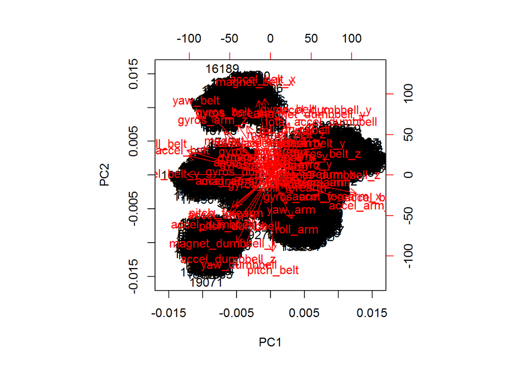

```r
library(stats)
training_pca <- prcomp(training[2:53], center = TRUE, scale = TRUE)
biplot(training_pca)
```

It appears that the principle components do segment the variables into five relatively distinct groupings.

Finally, split the training data set into a new training and validation data set.

```r
inTrain = createDataPartition(training$classe, p = .75)[[1]]
my_train = training[ inTrain,]
my_test = training[-inTrain,]
```

## Model Creation & Testing

Our next steps will involve creating a few different models to see how accurate they are at predicting the classe variable.

Because the outcome variable `classe` is a categorical variable, we cannot use linear or logistic regression. We will try a linear discrimanent model and a random forest model.

#### Linear Discriminant Model

```r
lda_model <- train(classe~.,data=my_train,method="lda")
lda_predict <- predict(lda_model,newdata=my_test)
confusionMatrix(table(lda_predict,my_test$classe))
```

```
## Confusion Matrix and Statistics
##
##
## lda_predict    A    B    C    D    E
##           A 1144  122   74   46   39
##           B   44  630   86   29  132
##           C   97  117  565  108   87
##           D  101   38  108  595   83
##           E    8   42   22   26  560
##
## Overall Statistics
##
##                Accuracy : 0.7126
##                  95% CI : (0.6997, 0.7253)
##     No Information Rate : 0.2843
##     P-Value [Acc > NIR] : < 2.2e-16
##
##                   Kappa : 0.6366
##  Mcnemar's Test P-Value : < 2.2e-16
##
## Statistics by Class:
##
##                      Class: A Class: B Class: C Class: D Class: E
## Sensitivity            0.8207   0.6639   0.6608   0.7400   0.6215
## Specificity            0.9199   0.9264   0.8990   0.9195   0.9755
## Pos Pred Value         0.8028   0.6840   0.5801   0.6432   0.8511
## Neg Pred Value         0.9281   0.9199   0.9262   0.9475   0.9197
## Prevalence             0.2843   0.1936   0.1744   0.1640   0.1838
## Detection Rate         0.2333   0.1285   0.1152   0.1214   0.1142
## Detection Prevalence   0.2906   0.1878   0.1987   0.1887   0.1342
## Balanced Accuracy      0.8703   0.7951   0.7799   0.8298   0.7985
```

#### Random Forest Model

```r
rf_model <- randomForest(classe~.,data=my_train)
print(rf_model)
```

```
##
## Call:
##  randomForest(formula = classe ~ ., data = my_train)
##                Type of random forest: classification
##                      Number of trees: 500
## No. of variables tried at each split: 7
##
##         OOB estimate of  error rate: 0.2%
## Confusion matrix:
##      A    B    C    D    E  class.error
## A 4184    1    0    0    0 0.0002389486
## B    5 2841    2    0    0 0.0024578652
## C    0    4 2563    0    0 0.0015582392
## D    0    0   13 2399    0 0.0053897181
## E    0    0    0    4 2702 0.0014781966
```

Above we have the in-sample error rate. Now we will check the out-of-sample error rate by cross-validating on the test data that we have held back.

```r
rf_predict <- predict(rf_model,newdata=my_test)
confusionMatrix(table(rf_predict,my_test$classe))
```

```
## Confusion Matrix and Statistics
##
##
## rf_predict    A    B    C    D    E
##          A 1394    2    0    0    0
##          B    0  947    4    0    0
##          C    0    0  851   13    0
##          D    0    0    0  791    3
##          E    0    0    0    0  898
##
## Overall Statistics
##
##                Accuracy : 0.9955
##                  95% CI : (0.9932, 0.9972)
##     No Information Rate : 0.2843
##     P-Value [Acc > NIR] : < 2.2e-16
##
##                   Kappa : 0.9943
##  Mcnemar's Test P-Value : NA
##
## Statistics by Class:
##
##                      Class: A Class: B Class: C Class: D Class: E
## Sensitivity            1.0000   0.9979   0.9953   0.9838   0.9967
## Specificity            0.9994   0.9990   0.9968   0.9993   1.0000
## Pos Pred Value         0.9986   0.9958   0.9850   0.9962   1.0000
## Neg Pred Value         1.0000   0.9995   0.9990   0.9968   0.9993
## Prevalence             0.2843   0.1936   0.1744   0.1640   0.1838
## Detection Rate         0.2843   0.1931   0.1736   0.1613   0.1832
## Detection Prevalence   0.2847   0.1940   0.1762   0.1619   0.1832
## Balanced Accuracy      0.9997   0.9984   0.9961   0.9915   0.9983
```

The above cross-validation for the Random Forest model indicates an out-of-sample error rate of around 0.004 or .4%.

Looking at the two models, the LDA model has an accuracy rating of only .71, while the Random Forest is .996.

Since the Random Forest is the more accurate of the two models, we will go with this one for constructing the final model.

## Final Model

The final model returns to using the full training set, and then predicts the `classe` values for the twenty rows in the testing set.

```r
final_model <- randomForest(classe~.,data=training)
predict_final <- predict(final_model,newdata=pml_testing)
testing_predicted <- pml_testing
testing_predicted$classe <- predict_final
print(testing_predicted$classe)
```

```
##  [1] B A B A A E D B A A B C B A E E A B B B
## Levels: A B C D E
```